# R and GIS, or R as GIS: handling spatial data: GIS and R: bridges or R as GIS?

### GEOS

A recent upgrade of GEOS from 3.7.1 to 3.7.2 on a CRAN test server led to failures in three packages using **rgeos** for topological operations. **rgeos** 0.4-3 set the `checkValidity=` argument to for example `gIntersection()` to FALSE (TRUE threw an error if either geometry was invalid). An [issue](https://github.com/r-spatial/sf/issues/1121) was opened on the **sf** github repository (**rgeos** is developed on R-Forge). The test objects (from an example from **inlmisc**) will be used here:

```r
rgeos::version_GEOS0()
```

```
## [1] "3.7.2"
## attr(,"rev")
## [1] "b55d2125"
```

For **rgeos** <= 0.4-3, the default was not to check input geometries for validity before trying topological operations, for >= 0.5-1, the default changes when GEOS > 3.7.1 to check for validity. The mode of the argument also changes to integer from logical:

```r
cV_old_default <- ifelse(rgeos::version_GEOS0() >= "3.7.2", 0L, FALSE)
yy <- rgeos::readWKT(readLines("data/invalid.wkt"))
rgeos::gIsValid(yy, byid=TRUE, reason=TRUE)
```

```
##                             1                             2
## "Ring Self-intersection[2 3]"              "Valid Geometry"
##                             3                             4
##              "Valid Geometry"              "Valid Geometry"
```

```r
sf::sf_extSoftVersion()
```

```
##           GEOS           GDAL         proj.4 GDAL_with_GEOS     USE_PROJ_H
##        "3.7.2"        "3.0.1"        "6.1.1"         "true"         "true"
```

The same underlyng GEOS code is used in **sf**:

```r
sf::st_is_valid(sf::st_as_sf(yy), reason=TRUE)
```

```
## [1] "Ring Self-intersection[2 3]" "Valid Geometry"
## [3] "Valid Geometry"              "Valid Geometry"
```

The geometries were also invalid in GEOS 3.7.1, but the operations succeeded:

```r
ply <- rgeos::readWKT(readLines("data/ply.wkt"))
oo <- try(rgeos::gIntersection(yy, ply, byid=TRUE, checkValidity=cV_old_default), silent=TRUE)
print(attr(oo, "condition")$message)
```

```
## [1] "TopologyException: Input geom 0 is invalid: Ring Self-intersection at or near point 2 3 at 2 3"
```

```r
ooo <- try(sf::st_intersection(sf::st_as_sf(yy), sf::st_as_sf(ply)), silent=TRUE)
print(attr(oo, "condition")$message)
```

```
## [1] "TopologyException: Input geom 0 is invalid: Ring Self-intersection at or near point 2 3 at 2 3"
```

In **rgeos** 0.5-1 and GEOS 3.7.2, new warnings are provided, and advice to check validity.

```r
cV_new_default <- ifelse(rgeos::version_GEOS0() >= "3.7.2", 1L, TRUE)
try(rgeos::gIntersection(yy, ply, byid=TRUE, checkValidity=cV_new_default), silent=TRUE)
```

```
## Warning in RGEOSUnaryPredFunc(spgeom, byid, "rgeos_isvalid"): Ring Self-
## intersection at or near point 2 3
```

```
## yy is invalid
```

```
## Warning in rgeos::gIntersection(yy, ply, byid = TRUE, checkValidity
## = cV_new_default): Invalid objects found; consider using
## set_RGEOS_CheckValidity(2L)
```

New options are provided, `get_RGEOS_CheckValidity()` and `set_RGEOS_CheckValidity()`, because in some packages the use of topological operations may happen through other packages, such as `raster::crop()` calling `rgeos::gIntersection()` without access to the arguments of the latter function.

If we follow the advice, zero-width buffering is used to try to rectify the invalidity:

```r
oo <- rgeos::gIntersection(yy, ply, byid=TRUE, checkValidity=2L)
```

```
## yy is invalid
```

```
## Attempting to make yy valid by zero-width buffering
```

```r
rgeos::gIsValid(oo)
```

```
## [1] TRUE
```

equivalently:

```r
oo <- rgeos::gIntersection(rgeos::gBuffer(yy, byid=TRUE, width=0), ply, byid=TRUE, checkValidity=1L)
rgeos::gIsValid(oo)
```

```
## [1] TRUE
```

and by extension to **sf** until GEOS 3.7.2 is accommodated:

```r
ooo <- sf::st_intersection(sf::st_buffer(sf::st_as_sf(yy), dist=0), sf::st_as_sf(ply))
all(sf::st_is_valid(ooo))
```

```
## [1] TRUE
```

The actual cause was the use of an ESRI/shapefile style/understanding of the self-touching exterior ring. In OGC style, an interior ring is required, but not in shapefile style. Martin Davis responded in the issue:

The change in GEOS behaviour was not planned as such, but has consequences, fortunately detected because CRAN checks by default much more than say Travis by default. Zero-width buffering will not repair all cases of invalidity, but does work here.

## GIS bridges (description and using GRASS and **rgrass7**)

```r
library(sf)
```

```r
olinda_sirgas2000 <- st_read("output/olinda_sirgas2000.gpkg", quiet=TRUE)
bounds <- st_sf(st_union(olinda_sirgas2000))
SG <- maptools::Sobj_SpatialGrid(as(bounds, "Spatial"), n=1000000)$SG
```

```r
library(rgrass7)
```

```r
use_sp()
myGRASS <- "/home/rsb/topics/grass/g761/grass76"
loc <- initGRASS(myGRASS, tempdir(), SG=SG, override=TRUE)
execGRASS("g.mapset", mapset="PERMANENT", flag="quiet")
execGRASS("g.proj", flag="c", proj4=st_crs(bounds)$proj4string)
```

```
## Default region was updated to the new projection, but if you have multiple
## mapsets `g.region -d` should be run in each to update the region from the
## default
## Projection information updated
```

```r
execGRASS("g.mapset", mapset=loc$MAPSET, flag="quiet")
execGRASS("g.region", flag="d")
```

```r
use_sp()
execGRASS("r.in.gdal", flag=c("overwrite", "quiet"), input="output/elevation.tif", output="dem")
execGRASS("g.region", raster="dem")
```

```r
execGRASS("r.watershed", flag=c("overwrite", "quiet"), elevation="dem", stream="stream", threshold=2500L, convergence=5L, memory=300L)
execGRASS("r.thin", flag=c("overwrite", "quiet"), input="stream", output="stream1", iterations=200L)
```

```r
use_sf()
writeVECT(bounds, "bounds", v.in.ogr_flags=c("overwrite", "quiet"))
```

```
## Writing layer `bounds' to data source `/tmp/Rtmp878vgu/file21e717aed63d/file21e733222bbb/.tmp/localhost.localdomain/684.0.gpkg' using driver `GPKG'
## options:        OVERWRITE=YES
## features:       1
## fields:         0
## geometry type:  Polygon
```

```r
execGRASS("r.mask", vector="bounds", flag=c("overwrite", "quiet"))
execGRASS("r.to.vect", flag=c("overwrite", "quiet"), input="stream1", output="stream", type="line")
```

```
## WARNING: Memory leak: 36 points are still in use
```

```r
imputed_streams <- readVECT("stream", ignore.stderr=TRUE)
```

```r
library(mapview)
mapview(imputed_streams)
```

[interactive chart not shown]

```r
execGRASS("r.slope.aspect", elevation="dem", slope="slope", aspect="aspect", flag=c("quiet", "overwrite"))
writeVECT(olinda_sirgas2000[, "SETOR_"], "olinda", ignore.stderr=TRUE, v.in.ogr_flags=c("overwrite", "quiet"))
execGRASS("v.rast.stats", map="olinda", raster=c("slope", "aspect"), method=c("first_quartile", "median", "third_quartile"), column_prefix=c("slope", "aspect"), flag=c("c", "quiet"))
```

```r
olinda_gmm <- readVECT("olinda", ignore.stderr=TRUE)
head(olinda_gmm)
```

```
## Simple feature collection with 6 features and 8 fields
## geometry type:  POLYGON
## dimension:      XY
## bbox:           xmin: 295330.3 ymin: 9119339 xmax: 296729.1 ymax: 9120522
## epsg (SRID):    NA
## proj4string:    +proj=utm +zone=25 +south +ellps=GRS80 +towgs84=0,0,0,0,0,0,0 +units=m +no_defs
##   cat SETOR_ slope_first_quartile slope_median slope_third_quartile
## 1   1      2             1.017030      2.55044              3.02056
## 2   2      3             1.270000      2.60012              3.04049
## 3   3      4             0.574040      2.57144              3.62007
## 4   4      5             0.136963      2.05871              2.98215
## 5   5      6             0.747998      2.62333              3.76261
## 6   6      7             0.503164      1.94426              2.80776
##   aspect_first_quartile aspect_median aspect_third_quartile
## 1               36.2456      117.8670               233.862
## 2               90.1409      135.0760               180.256
## 3               29.8119       89.2267               155.906
## 4                2.1586       90.2566               144.705
## 5               85.8933      123.0810               180.247
## 6               25.9332       83.2747               132.841
##                             geom
## 1 POLYGON ((295549.1 9120119,...
## 2 POLYGON ((295589.3 9120184,...
## 3 POLYGON ((295938.3 9120468,...
## 4 POLYGON ((295374.4 9119990,...
## 5 POLYGON ((295589.3 9120184,...
## 6 POLYGON ((296634.3 9119829,...
```

## Using R as a GIS (topological and other operations)

```r
water_buf_50 <- st_buffer(imputed_streams, dist=50)
setor_area <- st_area(olinda_sirgas2000)
near_water0 <- st_intersection(olinda_sirgas2000[,"SETOR_"], water_buf_50[,"cat"])
near_water <- aggregate(near_water0, by=list(near_water0$SETOR_), head, n=1)
```

```r
area_near_water <- st_area(near_water)
olinda_sirgas2000$setor_area <- setor_area
o <- match(near_water$SETOR_, olinda_sirgas2000$SETOR_)
olinda_sirgas2000$area_near_water <- 0
olinda_sirgas2000$area_near_water[o] <- area_near_water
olinda_sirgas2000$prop_near_water <- olinda_sirgas2000$area_near_water/olinda_sirgas2000$setor_area
summary(olinda_sirgas2000$prop_near_water)
```

```
##    Min. 1st Qu.  Median    Mean 3rd Qu.    Max.
## 0.00000 0.07342 0.19402 0.23066 0.35662 0.90232
```

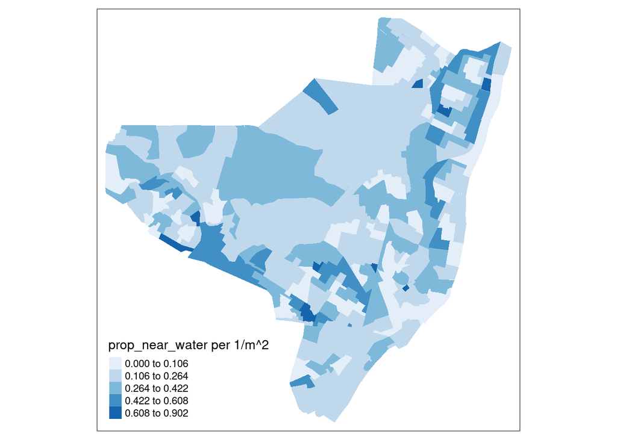

```r
library(tmap)
tm_shape(olinda_sirgas2000) + tm_fill("prop_near_water", palette="Blues", style="fisher", n=5)
```

```r
streams_by_setor <- st_intersection(olinda_sirgas2000[,"SETOR_"], imputed_streams[,"cat"])
lngths0 <- aggregate(streams_by_setor, by=list(streams_by_setor$SETOR_), head, n=1)
lngths <- st_length(lngths0)
units(lngths) <- "mm"
o <- match(lngths0$SETOR_, olinda_sirgas2000$SETOR_)
olinda_sirgas2000$lngths <- 0
olinda_sirgas2000$lngths[o] <- lngths
olinda_sirgas2000$lngth_area <- olinda_sirgas2000$lngths/olinda_sirgas2000$setor_area
```

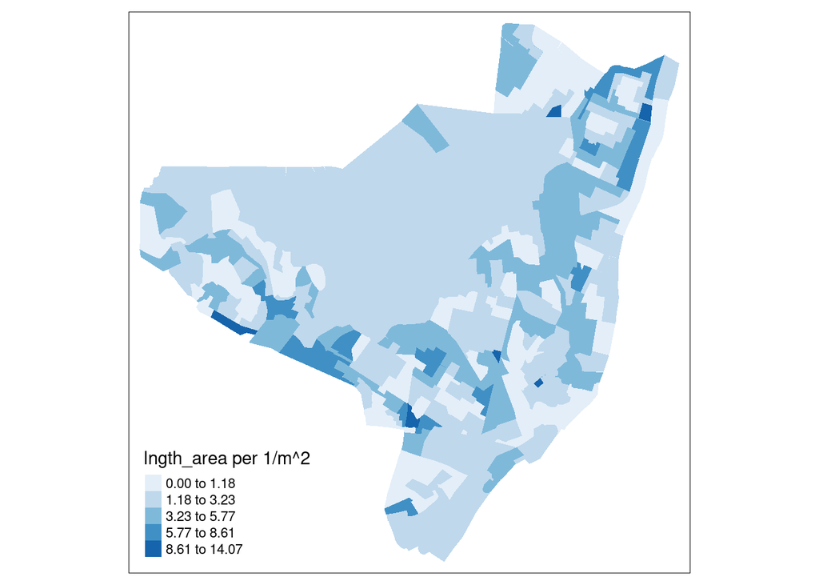

```r
tm_shape(olinda_sirgas2000) + tm_fill("lngth_area", palette="Blues", style="fisher", n=5)
```

```r
cor(olinda_sirgas2000$lngth_area, olinda_sirgas2000$prop_near_water)
```

```
## [1] 0.9655318
```

## Exercises and review

Evers, Kristian, and Thomas Knudsen. 2017. *Transformation Pipelines for Proj.4*. https://www.fig.net/resources/proceedings/fig_proceedings/fig2017/papers/iss6b/ISS6B_evers_knudsen_9156.pdf.

Knudsen, Thomas, and Kristian Evers. 2017. *Transformation Pipelines for Proj.4*. https://meetingorganizer.copernicus.org/EGU2017/EGU2017-8050.pdf.